# Estimando a Curva de Phillips para o Brasil

Marcos J Ribeiro

26/05/2020

## Questão 3

Alguns de vocês estão com dúvidas na questão 3. Vou resolver essa questão utilizando o R. O que vou fazer é semelhante ao que o Blanchard (5 ed) faz. Ele estima a equação 8.6, utilizando dados da economia americana.

$$\pi_t - \pi_{t-1} = (\mu + z) - \alpha u_t$$

Vou fazer algo semelhante utilizando dados do Brasil. Primeiro vamos obter os dados do Banco Central. O R facilita nossa vida nessa tarefa, existe uma biblioteca que faz isso de forma automática. Primeiro vou ‘chamar’ essa biblioteca:

```r
library(GetBCBData)   # para chamar a biblioteca que vou usar
library('xts')
```

Agora vou obter os dados diretamente do Banco Central, o código do IPCA é 433. Esses dados ficarão salvos em um objeto chamado inf.

```r
# inflation - Índice nacional de preços ao consumidor-amplo (IPCA)

inf = gbcbd_get_series(433, first.date= '1981-01-01', last.date = '2020-04-01',
                      format.data = "long", be.quiet = FALSE)[ ,1:2]

data = inf$ref.date
inf[,1]=NULL
colnames(inf) = 'inf'
inf = xts(inf, order.by = data)
```

Vou fazer um gráfico dessa série.

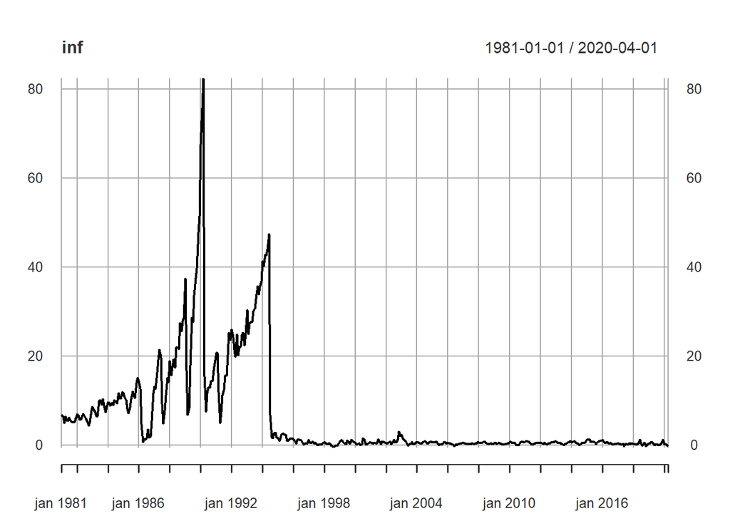

```r
plot(inf)
```

No item (a) temos:

(a)- Utilize o IPCA e calcule a variação da inflação nesse período,
$$π_t − π_{t−1}$$
.

Então vou fazer a primeira diferença da inflação e salvar em objeto chamado dinf:

```r
dinf = diff(inf)
colnames(dinf) = 'dinf'
```

Agora vou fazer o gráfico dessa série, que é o item b.

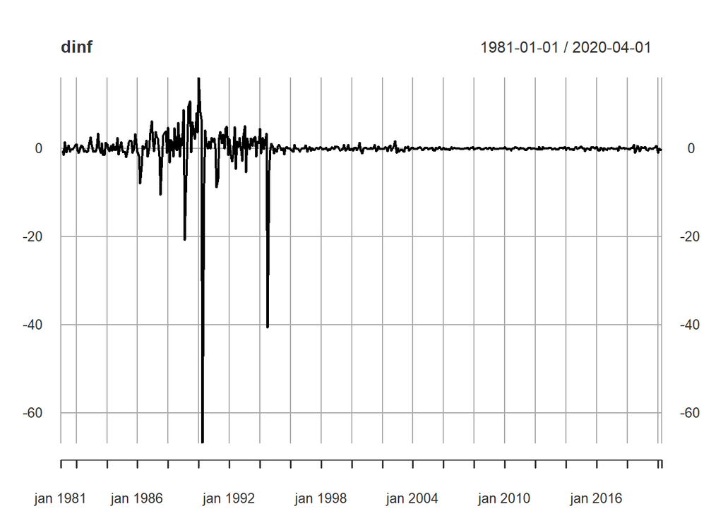

```r
plot(dinf)
```

Agora vou obter os dados do desemprego, utilizando a mesma rotina. Só que o código da taxa de desocupação é 24369.

```r
# unemployment  - Taxa de desocupação - PNADC

des = gbcbd_get_series(24369, first.date= '1981-01-01', last.date = '2020-04-01',
                       format.data = "long", be.quiet = FALSE)[ ,1:2]

data1 = des$ref.date
des[,1]=NULL
colnames(des) = 'des'
des = xts(des, order.by = data1)
```

Vamos ver o gráfico dessa série:

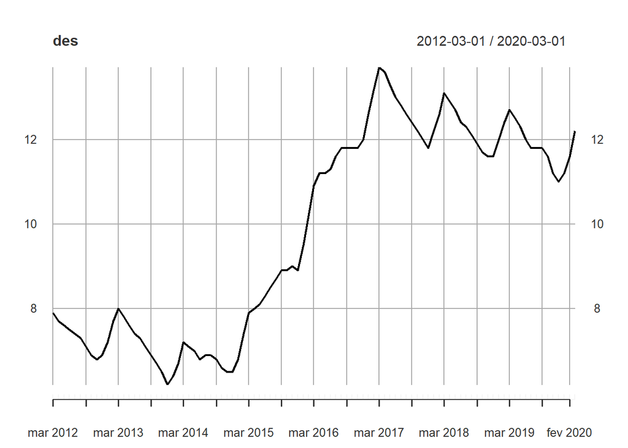

```r
plot(des)
```

Agora vou fazer o item c:

(c)- Faça um gráfico de dispersão com a variação da inflação no eixo y e a taxa desemprego no eixo x.

Para fazer isso vou utilizar uma biblioteca de visualização gráfica bastante poderosa. O ggplot2.

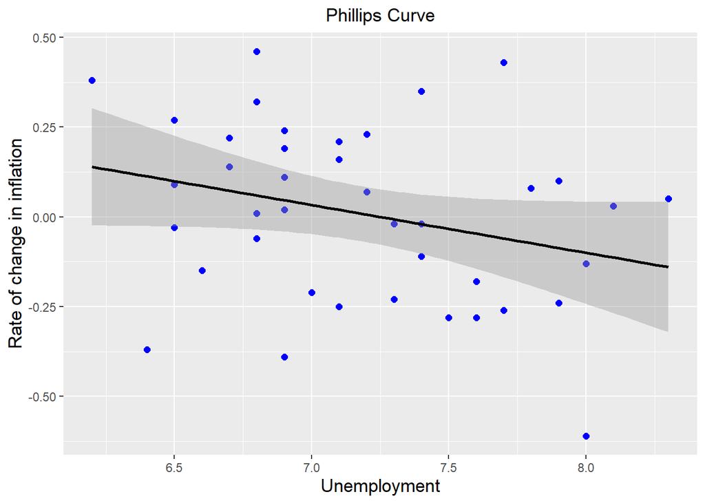

```r
library(ggplot2)


df = data.frame(des, dinf[index(des)],inf[index(des)])
data3 = index(inf)
dfinf = data.frame(data3, inf)

g1 = ggplot(data = df[1:40,], aes(x = `des`, y =`dinf`), alpha=0.5)

g1 + geom_point(color='blue', size=2) +
  ggtitle('Phillips Curve') +
  geom_smooth(method = 'lm',formula = y~x, color='black') +
  xlab('Unemployment') +
  ylab('Rate of change in inflation') +
  theme(axis.title.x = element_text(colour = 'black', size=13),
        axis.title.y = element_text(colour = 'black', size=13),
        plot.title = element_text(hjust = 0.5))
```

Por fim, vou estimar a regressão linear em que a variável dependente é a variação da inflação e a variável independente é a taxa de desemprego. Note que estou estimando a equação 8.6 do livro do Blanchard.

```r
reg1 = lm(dinf ~ des, data = df)
summary(reg1)
```

```
##
## Call:
## lm(formula = dinf ~ des, data = df)
##
## Residuals:
##      Min       1Q   Median       3Q      Max
## -0.92583 -0.17033  0.00192  0.19417  0.88317
##
## Coefficients:
##              Estimate Std. Error t value Pr(>|t|)
## (Intercept)  0.069835   0.130719   0.534    0.594
## des         -0.007501   0.012904  -0.581    0.562
##
## Residual standard error: 0.3094 on 95 degrees of freedom
## Multiple R-squared:  0.003544,   Adjusted R-squared:  -0.006945
## F-statistic: 0.3378 on 1 and 95 DF,  p-value: 0.5625
```